# Basic Inferential Data Analysis Instructions

Michael Steiner

October 12, 2017

## Load Data

#### Description

The response is the length of odontoblasts (teeth) in each of 10 guinea pigs at each of three dose levels of Vitamin C (0.5, 1, and 2 mg) with each of two delivery methods (orange juice or ascorbic acid).

#### Format

A data frame with 60 observations on 3 variables. [,1] len numeric Tooth length [,2] supp factor Supplement type (VC or OJ). [,3] dose numeric Dose in milligrams.

```r
library(datasets)
data("ToothGrowth")
```

## Summary

```r
ToothGrowth$dose <- as.factor(ToothGrowth$dose)
summary(ToothGrowth)
```

```
##       len        supp     dose
##  Min.   : 4.20   OJ:30   0.5:20
##  1st Qu.:13.07   VC:30   1  :20
##  Median :19.25           2  :20
##  Mean   :18.81
##  3rd Qu.:25.27
##  Max.   :33.90
```

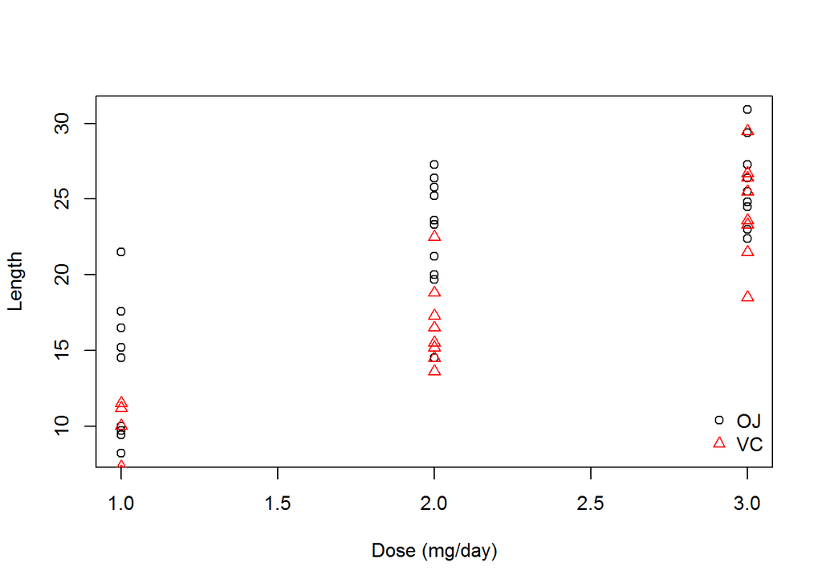

```r
oj <- ToothGrowth[ToothGrowth$supp %in% c('OJ'),]
vc <- ToothGrowth[ToothGrowth$supp %in% c('VC'),]
plot(as.numeric(oj$dose), oj$len, col = 1, pch = 1, xlab = 'Dose (mg/day)', ylab = 'Length', main = '')
points(as.numeric(vc$dose), vc$len, col = 2, pch = 2)
legend('bottomright', c("OJ", "VC") ,bty = "n", pch = c(1,2), col = c(col = 1, col = 2))
```

Preliminary analysis shows a general trend of longer teeth with increasing dosage of both Orange Juice and Vitamin C.

## Confidence intervals

```r
t.test(len ~ supp, data = ToothGrowth)
```

```
##
##  Welch Two Sample t-test
##
## data:  len by supp
## t = 1.9153, df = 55.309, p-value = 0.06063
## alternative hypothesis: true difference in means is not equal to 0
## 95 percent confidence interval:
##  -0.1710156  7.5710156
## sample estimates:
## mean in group OJ mean in group VC
##         20.66333         16.96333
```

The p-value is larger than the 5% significance level so the null hypthosis cannot be rejected.

```r
data("ToothGrowth")
t.test(ToothGrowth$len, ToothGrowth$dose)
```

```
##
##  Welch Two Sample t-test
##
## data:  ToothGrowth$len and ToothGrowth$dose
## t = 17.81, df = 59.798, p-value < 2.2e-16
## alternative hypothesis: true difference in means is not equal to 0
## 95 percent confidence interval:
##  15.66453 19.62881
## sample estimates:
## mean of x mean of y
## 18.813333  1.166667
```